# 260 Final Project: Boston House Price Prediction

Vivian Shao

2022-12-06

# Introduction

The goal of this project is to answer two key questions. First, how successfully can I apply the machine learning methods I’ve learned in this course on input features to predict the price of houses in Boston? Second, how do the performances of linear regressions and random forests compare on the same dataset? The dataset was from a research paper titled “Hedonic prices and the demand for clean air” which was authored by David Harrison and Daniel L. Rubenfield in 1978.

The dataset has 506 observations of 13 predictors with the output being the median value of owner-occupied homes in $1000s.

### Feature Description

1. CRIM: per capita crime rate by town
2. ZN: proportion of residential land zoned for lots over 25,000 sq.ft.
3. INDUS: proportion of non-retail business acres per town
4. CHAS: Charles River dummy variable (1 if tract bounds river; 0 otherwise)
5. NOX: nitric oxides concentration (parts per 10 million) [parts/10M]
6. RM: average number of rooms per dwelling
7. AGE: proportion of owner-occupied units built prior to 1940
8. DIS: weighted distances to five Boston employment centres
9. RAD: index of accessibility to radial highways
10. TAX: full-value property-tax rate per $10,000 [$/10k]
11. PTRATIO: pupil-teacher ratio by town
12. B: The result of the equation B=1000(Bk - 0.63)^2 where Bk is the proportion of black people by town
13. LSTAT: % lower status of the population

```r
dat <- read.csv("boston.csv")
head(dat)
```

```
##      CRIM ZN INDUS CHAS   NOX    RM  AGE    DIS RAD TAX PTRATIO      B LSTAT
## 1 0.00632 18  2.31    0 0.538 6.575 65.2 4.0900   1 296    15.3 396.90  4.98
## 2 0.02731  0  7.07    0 0.469 6.421 78.9 4.9671   2 242    17.8 396.90  9.14
## 3 0.02729  0  7.07    0 0.469 7.185 61.1 4.9671   2 242    17.8 392.83  4.03
## 4 0.03237  0  2.18    0 0.458 6.998 45.8 6.0622   3 222    18.7 394.63  2.94
## 5 0.06905  0  2.18    0 0.458 7.147 54.2 6.0622   3 222    18.7 396.90  5.33
## 6 0.02985  0  2.18    0 0.458 6.430 58.7 6.0622   3 222    18.7 394.12  5.21
##   MEDV
## 1 24.0
## 2 21.6
## 3 34.7
## 4 33.4
## 5 36.2
## 6 28.7
```

### Exploratory Data Analysis

To better understand the dataset and build a prediction model, I performed some exploratory data analysis.

[figure not shown]

```r
dat <- read.csv("boston.csv")
dat.cor <- cor(dat)
corrplot(dat.cor,
         method = "shade",
         type = "full",
         diag = TRUE,
         tl.col = "black",
         bg = "white",
         col = NULL)
```

In the first plot, which is a correlation matrix, we can see which predictors are most correlated with the desired output. The darker the color, the stronger the correlation. Some significant covariates include RM (average number of rooms per house) and LSTAT (% of the population that’s lower status).

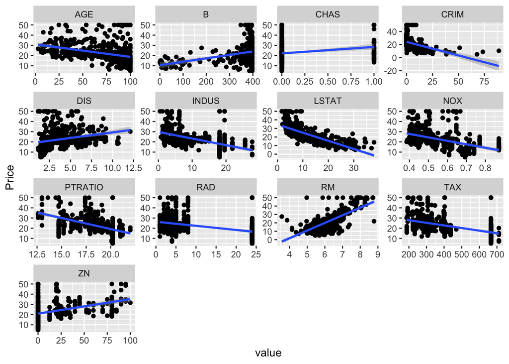

```r
dat |>
  gather(-MEDV, key = "var", value = "value") |>
  ggplot(aes(x = value, y = MEDV)) +
  geom_point() +
  geom_smooth(method = 'lm') +
  facet_wrap(~ var, scales = "free") +
  ylab('Price')
```

In the second EDA plot, I plotted every variable in a facet plot to better understand the positive, negative, or even insignificant linear relationship each variable has with the house price. Additionally, I can get a sense of the data distribution for each predictor. For example, it’s clear from this plot that CHAS (the location in relation to the Charles River) is binary and therefore, should be adjusted for accordingly when building the models.

Based on the largely continuous data and the continuous outcome in the dataset, I decided to use two predictive models we’ve learned this semester: multivariate linear regression and random forest. Additionally, I will be using k-fold cross validation to prevent overfitting and to evaluate the performance of my models. For both models, I will be using the R-squared value to compare prediction accuracy. I believe the comparison of a parametric and non-parametric model on the same dataset will be interesting insight.

# Results

In order to perform the k-fold cross validation and also measure how well it is able to create predictions on unseen data, I first split my dataset randomly into 80% that would be fed into the cross-validation and create a cross-validated model. Then, I used the 20% I held out from the cross validation to use as unseen data to test the cross-validated model’s predictive performance. Therefore, 404 of the 506 observations were used randomly chosen to be used when cross-validation and the remaining 102 observations were used to make new predictions. There is not reason for my splitting of the data using an 80/20 split because I am not splitting my data with the same purpose as a traditional 80/20 train-test split. Instead, I wanted to ensure that I could allocate enough data for my cross-validated model while still having enough “unseen” data for my eventual model evaluation.

Additionally, based on the initial exploratory data analysis where I found that the CHAS variable was binary, I used the as.factor() tranform it before using it for modeling.

```r
set.seed(10)
dat <- read.csv("boston.csv")
split <- sample(1:nrow(dat), floor(0.8*nrow(dat)))

#cv dataset
old <- dat[split,]
old$CHAS <- as.factor(old$CHAS)

#held-out dataset
new <- dat[-split,]
new$CHAS <- as.factor(new$CHAS)
```

To create the held-out dataset which I will use for evaluation, I split the dataset and took away the 14th column to save it as the results column. In doing so, my model will be able to create predictions objectively without influence from the actual MEDV observations. Therefore, when testing the cross-validated model, I only input columns 1 to 13 which were the predictors.

```r
new_true <- new[14]
new_true_vector <- new_true[['MEDV']]
new_dat <- new[1:13]
```

### Linear Regression

The first model I built was a multivariate linear regression model using k-fold cross validation. To begin, I fit a linear model on the data and analyzed the model summary. It’s important to note from this initial model summary which variables are statistically significant and provide the most predictive power. We can see that variables such as LSTAT and RM are extremely statistically significant and these findings also align with our initial data analysis.

```r
mod1 <- lm(MEDV ~ ., data = old)
summary(mod1)
```

```
##
## Call:
## lm(formula = MEDV ~ ., data = old)
##
## Residuals:
##      Min       1Q   Median       3Q      Max
## -14.6092  -2.7220  -0.5774   1.7397  25.9586
##
## Coefficients:
##               Estimate Std. Error t value Pr(>|t|)
## (Intercept)  38.177696   5.780878   6.604 1.31e-10 ***
## CRIM         -0.077279   0.052417  -1.474 0.141205
## ZN            0.037210   0.015294   2.433 0.015425 *
## INDUS         0.013338   0.073135   0.182 0.855383
## CHAS1         2.750736   1.068721   2.574 0.010425 *
## NOX         -18.381466   4.358511  -4.217 3.08e-05 ***
## RM            3.524380   0.473022   7.451 6.03e-13 ***
## AGE           0.004915   0.014832   0.331 0.740522
## DIS          -1.426138   0.221958  -6.425 3.84e-10 ***
## RAD           0.264717   0.076744   3.449 0.000623 ***
## TAX          -0.011338   0.004333  -2.617 0.009223 **
## PTRATIO      -0.968737   0.151327  -6.402 4.42e-10 ***
## B             0.010705   0.003286   3.257 0.001223 **
## LSTAT        -0.540427   0.058027  -9.313  < 2e-16 ***
## ---
## Signif. codes:  0 '***' 0.001 '**' 0.01 '*' 0.05 '.' 0.1 ' ' 1
##
## Residual standard error: 4.876 on 390 degrees of freedom
## Multiple R-squared:  0.7186, Adjusted R-squared:  0.7092
## F-statistic:  76.6 on 13 and 390 DF,  p-value: < 2.2e-16
```

I then began to build my predictive model using the Caret package and the trainControl() function to specify the number of folds. An important aspect of cross-validation I experimented with was whether the number of folds in cross validation significantly impacted the model’s predictive performance. To better understand this, I plotted the overall r-squared value of the cross validated linear regression model based on different numbers of folds.

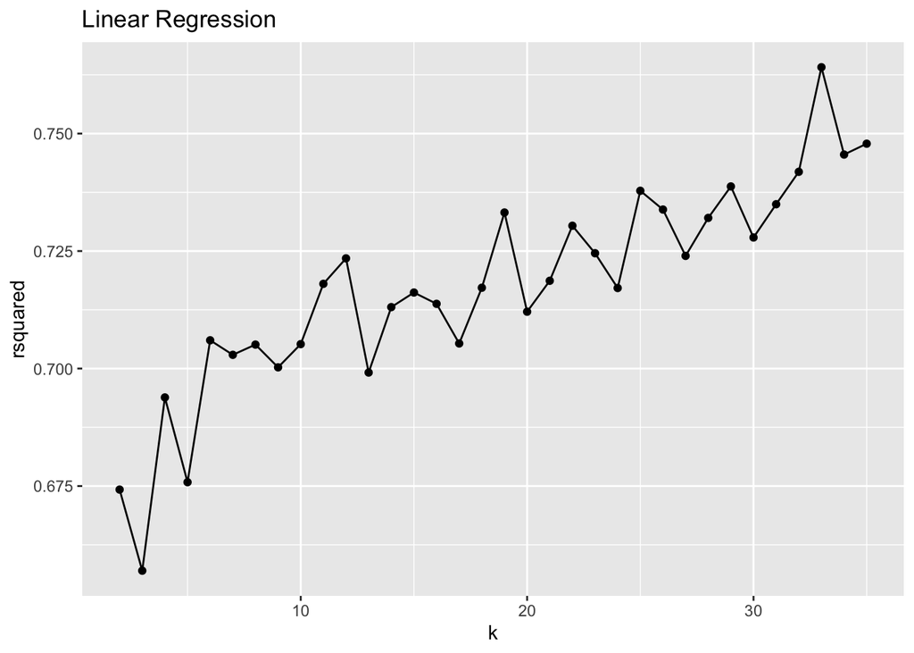

```r
columns = c("k", "rsquared")
test <- data.frame(matrix(nrow = 1, ncol = length(columns)))
colnames(test) = columns
for(i in 2:35){
  new <- rep(i, ncol(test))
  test[nrow(test) + 1, ] <- new
  ctrl <- trainControl(method = "cv", number = i)
  model <- train(MEDV ~ ., data = old, method = "lm", trControl = ctrl)
  test$k[i] <- i
  test$rsquared[i] <- model$results[1,3]
}
ggplot(data=test, aes(x=k, y=rsquared)) +
  geom_line()+
  geom_point()+ggtitle("Linear Regression")
```

As we can see from the plot, overall, there’s an upwards trend where as k increases, so does the model’s overall r-squared value. However, we can see there’s also a lot of variation between points. In the end, I chose to use 10-fold cross validation for my linear regression model because its performance seemed consistent.

To double check, I also graphed the RMSE. This verified my findings from above when I used r-squared.

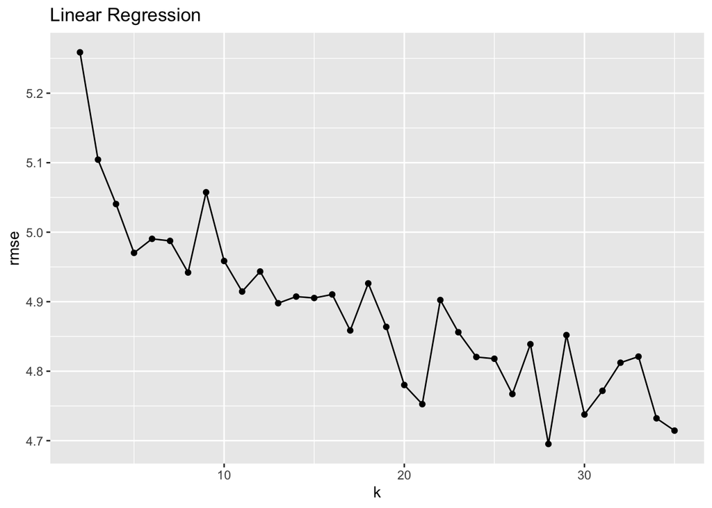

```r
columns = c("k", "rmse")
test <- data.frame(matrix(nrow = 1, ncol = length(columns)))
colnames(test) = columns
for(i in 2:35){
  new <- rep(i, ncol(test))
  test[nrow(test) + 1, ] <- new
  ctrl <- trainControl(method = "cv", number = i)
  model <- train(MEDV ~ ., data = old, method = "lm", trControl = ctrl)
  test$k[i] <- i
  test$rmse[i] <- model$results[1,2]
}
ggplot(data=test, aes(x=k, y=rmse)) +
  geom_line()+
  geom_point()+ggtitle("Linear Regression")
```

After creating a cross-validated model using the code below, we can, once again, print the model summary which overall performance of the model, given its performance on each fold.

```r
ctrl_lm <- trainControl(method = "cv", number = 10)
model_lm <- train(MEDV ~ ., data = old, method = "lm", trControl = ctrl_lm)
print(model_lm)
```

```
## Linear Regression
##
## 404 samples
##  13 predictor
##
## No pre-processing
## Resampling: Cross-Validated (10 fold)
## Summary of sample sizes: 363, 364, 363, 362, 364, 365, ...
## Resampling results:
##
##   RMSE     Rsquared   MAE
##   4.90471  0.7091684  3.510464
##
## Tuning parameter 'intercept' was held constant at a value of TRUE
```

```r
print(model_lm$resample)
```

```
##        RMSE  Rsquared      MAE Resample
## 1  5.855003 0.6510302 3.834273   Fold01
## 2  5.281898 0.6494258 3.623808   Fold02
## 3  4.428367 0.7264326 3.259004   Fold03
## 4  7.166912 0.5683772 4.354843   Fold04
## 5  4.217649 0.7594249 3.021822   Fold05
## 6  3.379411 0.7788667 2.754668   Fold06
## 7  3.627867 0.8447056 2.765236   Fold07
## 8  4.287221 0.8339589 3.143411   Fold08
## 9  3.872389 0.8005424 3.221766   Fold09
## 10 6.930388 0.4789201 5.125813   Fold10
```

```r
print(model_lm$finalModel)
```

```
##
## Call:
## lm(formula = .outcome ~ ., data = dat)
##
## Coefficients:
## (Intercept)         CRIM           ZN        INDUS        CHAS1          NOX
##   38.177696    -0.077279     0.037210     0.013338     2.750736   -18.381466
##          RM          AGE          DIS          RAD          TAX      PTRATIO
##    3.524380     0.004915    -1.426138     0.264717    -0.011338    -0.968737
##           B        LSTAT
##    0.010705    -0.540427
```

I then moved on to generating new predictions on unseen data using this cross-validated model using the predict() function. This allows me to calculate the model’s r-squared value by comparing the predicted house prices with the actual observed house prices.

```r
new_prediction <- predict(model_lm, newdata=new_dat)
new_prediction <- as.numeric(new_prediction)
new_true <- as.numeric(new_true_vector)

cor(new_true, new_prediction)^2
```

```
## [1] 0.8075232
```

### Random Forest

My next method was using a non-parametric model, random forest. Although there are some cases when a linear regression can outperform a random forest such as when the underlying function is truly linear, I believed that random forest would probably outperform the linear regression model in this project based on my prior experience and knowledge. The benefit of a random forest is that it’s robust to outliers and nonlinear data while also able to handle unbalanced data. Additionally, because random forests are an ensemble machine learning algorithm and averages the decision trees, random forests have low bias and moderate variance.

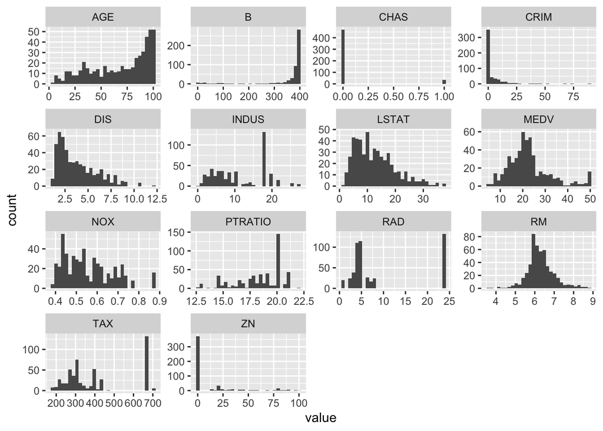

```r
dat |>
  gather() |>
  ggplot(aes(value)) +
  facet_wrap(~ key, scales = "free") +
  geom_histogram(bins = 30)
```

Here, I plotted the distribution of each covariate and their count. The plot shows that some variables such as RM (number of rooms) are relatively normal distributed. However, other distributions are skewed and such as RAD (accessibility to radial highways). . Unlike the cross validation for linear model, the cross validation for random forest actually selects the final model by outputting the most optimal mtry which is the number of variables to randomly sample as candidates at each split. I experimented with the number of folds and saw the best r-squared at 10 folds, although the benefit was pretty small. Additionally, I set the tunelength to be 10 in my train() function to observe how the number of variables randomly sampled as candidates at each split can impact the model’s performance.

```r
set.seed(10)
control <- trainControl(method='cv',
                        number=10,
                        search = 'random')
rf_random <- train(MEDV ~ .,
                   data = old,
                   method = 'rf',
                   metric = 'Rsquared',
                   tuneLength  = 10,
                   trControl = control)
print(rf_random)
```

```
## Random Forest
##
## 404 samples
##  13 predictor
##
## No pre-processing
## Resampling: Cross-Validated (10 fold)
## Summary of sample sizes: 364, 363, 363, 363, 363, 364, ...
## Resampling results across tuning parameters:
##
##   mtry  RMSE      Rsquared   MAE
##    3    3.429923  0.8674413  2.300892
##    6    3.247348  0.8735693  2.222601
##    7    3.244271  0.8746873  2.224622
##    8    3.186096  0.8772092  2.194748
##   10    3.248403  0.8708391  2.228277
##   12    3.204338  0.8733523  2.222294
##
## Rsquared was used to select the optimal model using the largest value.
## The final value used for the model was mtry = 8.
```

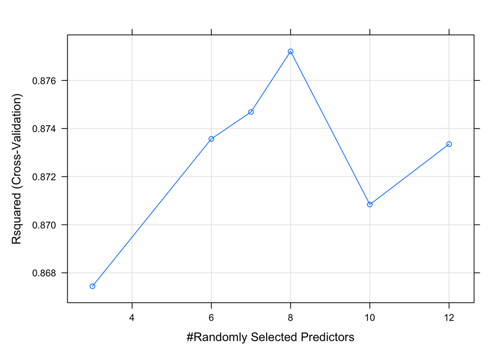

```r
plot(rf_random)
```

```r
rf_random$resample
```

```
##        RMSE  Rsquared      MAE Resample
## 1  2.539109 0.9182657 1.831180   Fold04
## 2  3.093713 0.9089507 2.041672   Fold09
## 3  3.215980 0.8832607 2.074490   Fold02
## 4  3.130918 0.8406907 2.222489   Fold05
## 5  2.735806 0.9252174 2.169524   Fold03
## 6  3.513056 0.7591351 2.544553   Fold01
## 7  2.297738 0.9583007 1.813947   Fold07
## 8  3.613509 0.8710782 2.282453   Fold10
## 9  4.233935 0.8108380 2.843767   Fold08
## 10 3.487198 0.8963546 2.123409   Fold06
```

```r
set.seed(10)
new_prediction_rf <- predict(rf_random, newdata=new_dat)
new_prediction_rf <- as.numeric(new_prediction_rf)
new_true_rf <- as.numeric(new_true_vector)

cor(new_true_rf, new_prediction_rf)^2
```

```
## [1] 0.9228545
```

# Conclusion

I used this project to compare two models, the linear regression and the random forest, and how well I can predict house prices given several different house features.

As mentioned earlier in the introduction, I had two main questions I sought to answer. First, how successfully can I apply the machine learning methods I’ve learned in this course on input features to predict the price of houses in Boston? Second, how do the performances of linear regressions and random forests compare on the same dataset?

Overally, I was able to obtain satisfactory predictive performance based on the r-squared values.

Additionally, we can see from our model comparison that the random forest performed significantly better than the linear regression on the Boston house price data. By cross-validating, we were able to not only prevent overfitting of the data but also select the best final model for predictions. However, despite the improved performance of the random forest predictive model, we also can see, first-hand, some of the drawbacks when using a non-parametric model. First, the random forest was noticeably slower than the linear regression model when cross-validating and predicting. In this project, the increased time was inconsequential because of the relatively small dataset, but for more robust datasets, I can see this potentially being an issue.

Second, random forests are a black box algorithm so while its complexity compared to the linear model lends itself to better predictions, it is less interpretable than a linear model. We can no longer understand the effects of the coefficients and the final random forest model as well as our final linear model. Therefore, this project has also showed the importance of not blindly choosing the more complex model. For datasets that meet the assumptions of a linear model and where linear models can also perform well, there is no benefit in using a random forest because we give up the power of interpretability.

Overall, I believe my analysis was successful because I was able to train two different algorithms and create predictions while also comparing the advantages and disadvantages of both. If I had more time, I would like to explore using other types of models like Naive Bayes or further exploring how I can tranform my covariates in the lienar model for better fit.

# References

Fedesoriano. (2021, June 1). Boston house prices-advanced regression techniques. Kaggle. Retrieved December 8, 2022, from https://www.kaggle.com/datasets/fedesoriano/the-boston-houseprice-data

# Appendix: All Code for the Project

```r
knitr::opts_chunk$set(echo = TRUE)
knitr::opts_chunk$set(warning = FALSE, message = FALSE)
library(corrplot)
library(ggplot2)
library(tidyr)
library(caret)
dat <- read.csv("boston.csv")
head(dat)
dat <- read.csv("boston.csv")
dat.cor <- cor(dat)
corrplot(dat.cor,
         method = "shade",
         type = "full",
         diag = TRUE,
         tl.col = "black",
         bg = "white",
         col = NULL)
dat |>
  gather(-MEDV, key = "var", value = "value") |>
  ggplot(aes(x = value, y = MEDV)) +
  geom_point() +
  geom_smooth(method = 'lm') +
  facet_wrap(~ var, scales = "free") +
  ylab('Price')
set.seed(10)
dat <- read.csv("boston.csv")
split <- sample(1:nrow(dat), floor(0.8*nrow(dat)))

#cv dataset
old <- dat[split,]
old$CHAS <- as.factor(old$CHAS)

#held-out dataset
new <- dat[-split,]
new$CHAS <- as.factor(new$CHAS)
new_true <- new[14]
new_true_vector <- new_true[['MEDV']]
new_dat <- new[1:13]
mod1 <- lm(MEDV ~ ., data = old)
summary(mod1)
columns = c("k", "rsquared")
test <- data.frame(matrix(nrow = 1, ncol = length(columns)))
colnames(test) = columns
for(i in 2:35){
  new <- rep(i, ncol(test))
  test[nrow(test) + 1, ] <- new
  ctrl <- trainControl(method = "cv", number = i)
  model <- train(MEDV ~ ., data = old, method = "lm", trControl = ctrl)
  test$k[i] <- i
  test$rsquared[i] <- model$results[1,3]
}
ggplot(data=test, aes(x=k, y=rsquared)) +
  geom_line()+
  geom_point()+ggtitle("Linear Regression")
columns = c("k", "rmse")
test <- data.frame(matrix(nrow = 1, ncol = length(columns)))
colnames(test) = columns
for(i in 2:35){
  new <- rep(i, ncol(test))
  test[nrow(test) + 1, ] <- new
  ctrl <- trainControl(method = "cv", number = i)
  model <- train(MEDV ~ ., data = old, method = "lm", trControl = ctrl)
  test$k[i] <- i
  test$rmse[i] <- model$results[1,2]
}
ggplot(data=test, aes(x=k, y=rmse)) +
  geom_line()+
  geom_point()+ggtitle("Linear Regression")
ctrl_lm <- trainControl(method = "cv", number = 10)
model_lm <- train(MEDV ~ ., data = old, method = "lm", trControl = ctrl_lm)
print(model_lm)
print(model_lm$resample)
print(model_lm$finalModel)
new_prediction <- predict(model_lm, newdata=new_dat)
new_prediction <- as.numeric(new_prediction)
new_true <- as.numeric(new_true_vector)

cor(new_true, new_prediction)^2
dat |>
  gather() |>
  ggplot(aes(value)) +
  facet_wrap(~ key, scales = "free") +
  geom_histogram(bins = 30)
set.seed(10)
control <- trainControl(method='cv',
                        number=10,
                        search = 'random')
rf_random <- train(MEDV ~ .,
                   data = old,
                   method = 'rf',
                   metric = 'Rsquared',
                   tuneLength  = 10,
                   trControl = control)
print(rf_random)
plot(rf_random)
rf_random$resample
set.seed(10)
new_prediction_rf <- predict(rf_random, newdata=new_dat)
new_prediction_rf <- as.numeric(new_prediction_rf)
new_true_rf <- as.numeric(new_true_vector)

cor(new_true_rf, new_prediction_rf)^2
```